# AEA Formal Privacy Questionnaire Analysis

### 4.7 Question 7

Q3_7 - Differential privacy/formal privacy is an approach to protecting privacy that distorts the results more than necessary given the actual risks.

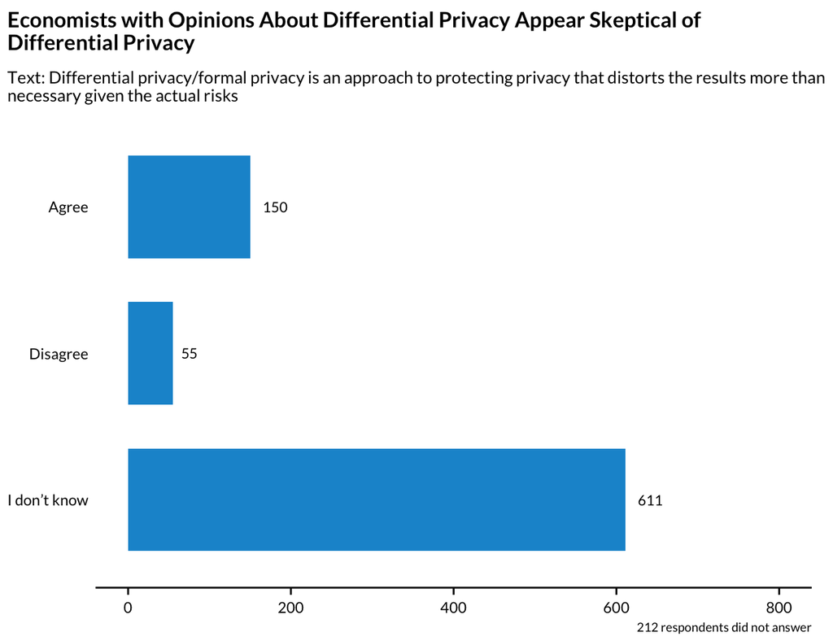

```r
aea %>%
  count(Q3_7) %>%
  filter(n != 212) %>%
  mutate(Q3_7 = fct_rev(Q3_7)) %>%
  ggplot(aes(n, Q3_7)) +
  geom_col() +
  geom_text(aes(label = n, hjust = -0.5)) +
  scale_x_continuous(limits = c(NA, 800)) +
  labs(
    title = "Economists with Opinions About Differential Privacy Appear Skeptical of\nDifferential Privacy",
    subtitle = "Text: Differential privacy/formal privacy is an approach to protecting privacy that distorts the results more than\nnecessary given the actual risks",
    x = NULL,
    y = NULL,
    caption = "212 respondents did not answer"
  ) +
  theme(panel.grid = element_blank())
```

### 4.8 Question 8

Q3_8 - Differential privacy/formal privacy is a needed approach to preserve privacy in the face of expanding disclosure risks that current methods are unable to address.

[figure not shown]

```r
aea %>%
  count(Q3_8) %>%
  filter(n != 215) %>%
  mutate(Q3_8 = fct_rev(Q3_8)) %>%
  ggplot(aes(n, Q3_8)) +
  geom_col() +
  geom_text(aes(label = n, hjust = -0.5)) +
  scale_x_continuous(limits = c(NA, 800)) +
  labs(
    title = "Economists with Opinions About Differential Privacy Appear Skeptical of\nDifferential Privacy",
    subtitle = "Text: Differential privacy/formal privacy is a needed approach to preserve privacy in the face of expanding\ndisclosure risks that current methods are unable to address",
    x = NULL,
    y = NULL,
    caption = "215 respondents did not answer"
  ) +
  theme(panel.grid = element_blank())
```

## 5 Section 4

### 5.1 Question 1

- What is the largest percentage of significance mismatch you would accept before…?

```r
count(aea, is.na(Q4_1_1))
```

| is.na(Q4_1_1) | n |
| --- | --- |
| FALSE | 473 |
| TRUE | 555 |

```r
count(aea, is.na(Q4_1_2))
```

| is.na(Q4_1_2) | n |
| --- | --- |
| FALSE | 467 |
| TRUE | 561 |

```r
probs <- c(0, 0.05, 0.25, 0.5, 0.75, 0.95, 1)

aea %>%
  summarize(
    probs = probs,
    sig_mismatch = quantile(Q4_1_1, probs = probs, na.rm = TRUE)
  )
```

| probs | sig_mismatch |
| --- | --- |
| 0.00 | 0 |
| 0.05 | 0 |
| 0.25 | 5 |
| 0.50 | 10 |
| 0.75 | 20 |
| 0.95 | 50 |
| 1.00 | 100 |

```r
aea %>%
  summarize(
    probs = probs,
    sig_mismatch = quantile(Q4_1_2, probs = probs, na.rm = TRUE)
  )
```

| probs | sig_mismatch |
| --- | --- |
| 0.00 | 0.0 |
| 0.05 | 0.5 |
| 0.25 | 5.0 |
| 0.50 | 10.0 |
| 0.75 | 20.0 |
| 0.95 | 50.0 |
| 1.00 | 100.0 |

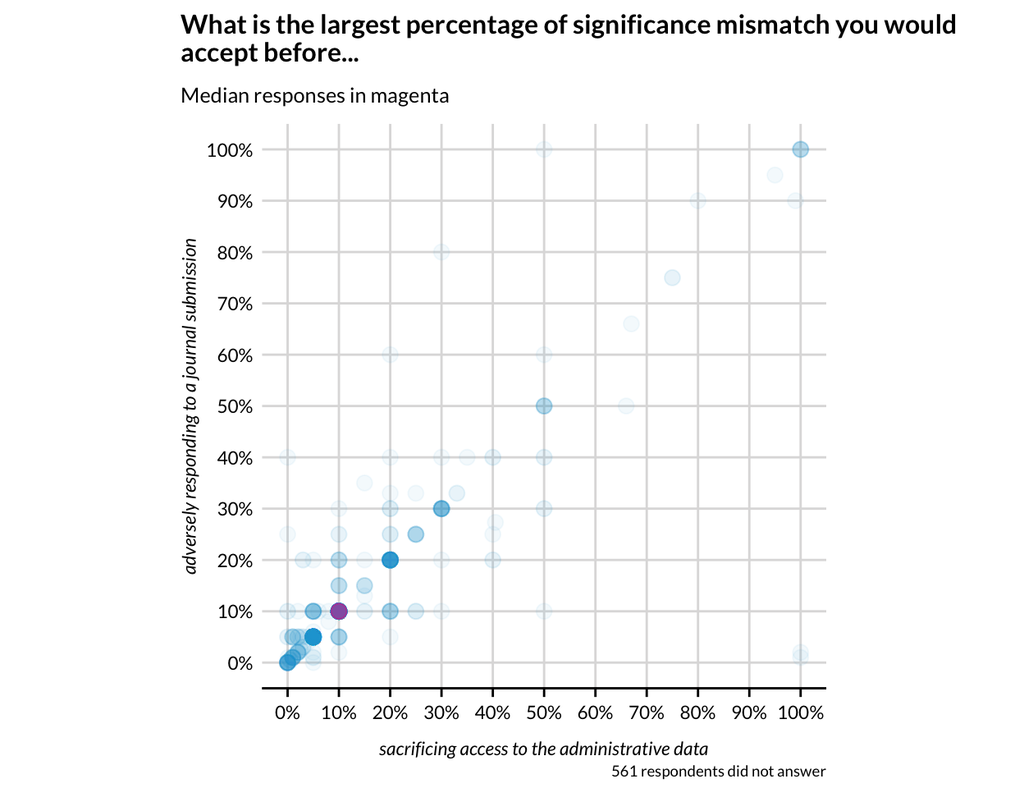

```r
ggplot() +
  geom_point(
    data = aea,
    mapping = aes(Q4_1_1 / 100, Q4_1_2 / 100),
    alpha = 0.05
  ) +
  geom_point(
    data = summarize(aea, Q4_1_1 = median(Q4_1_1, na.rm = TRUE), Q4_1_2 = median(Q4_1_2, na.rm = TRUE)),
    mapping = aes(Q4_1_1 / 100, Q4_1_2 / 100),
    alpha = 0.5,
    color = "#ec008b"
  ) +
  scale_x_continuous(breaks = seq(0, 1, 0.1), labels = scales::percent_format(accuracy = 1)) +
  scale_y_continuous(breaks = seq(0, 1, 0.1), labels = scales::percent_format(accuracy = 1)) +
  scatter_grid() +
  coord_equal() +
  labs(
    title = "What is the largest percentage of significance mismatch you would\naccept before...",
    subtitle = "Median responses in magenta",
    x = "sacrificing access to the administrative data",
    y = "adversely responding to a journal submission",
    caption = "561 respondents did not answer"
  )
```

### 5.2 Question 2

What is the largest percentage of sign mismatch you would accept before…?

*This is more conservative than significance, which seems good.*

```r
count(aea, is.na(Q4_2_1))
```

| is.na(Q4_2_1) | n |
| --- | --- |
| FALSE | 470 |
| TRUE | 558 |

```r
count(aea, is.na(Q4_2_2))
```

| is.na(Q4_2_2) | n |
| --- | --- |
| FALSE | 465 |
| TRUE | 563 |

```r
probs <- c(0, 0.05, 0.25, 0.5, 0.75, 0.95, 1)

aea %>%
  summarize(
    probs = probs,
    sign_mismatch = quantile(Q4_2_1, probs = probs, na.rm = TRUE)
  )
```

| probs | sign_mismatch |
| --- | --- |
| 0.00 | 0.000 |
| 0.05 | 0.000 |
| 0.25 | 0.325 |
| 0.50 | 5.000 |
| 0.75 | 10.000 |
| 0.95 | 25.000 |
| 1.00 | 100.000 |

```r
aea %>%
  summarize(
    probs = probs,
    sign_mismatch = quantile(Q4_2_2, probs = probs, na.rm = TRUE)
  )
```

| probs | sign_mismatch |
| --- | --- |
| 0.00 | 0 |
| 0.05 | 0 |
| 0.25 | 1 |
| 0.50 | 5 |
| 0.75 | 10 |
| 0.95 | 25 |
| 1.00 | 100 |

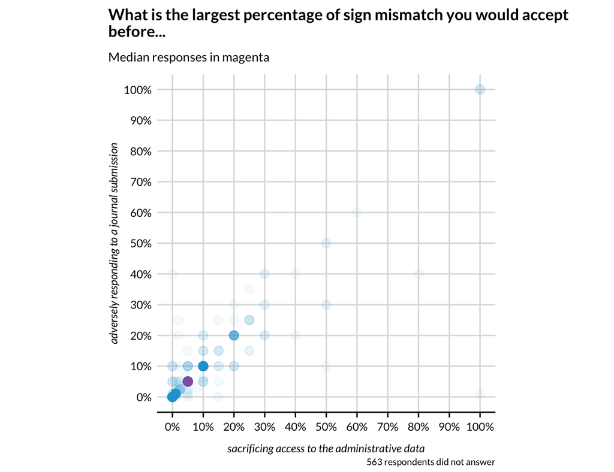

```r
ggplot() +
  geom_point(
    data = aea,
    mapping = aes(Q4_2_1 / 100, Q4_2_2 / 100),
    alpha = 0.05
  ) +
  geom_point(
    data = summarize(aea, Q4_2_1 = median(Q4_2_1, na.rm = TRUE), Q4_2_2 = median(Q4_2_2, na.rm = TRUE)),
    mapping = aes(Q4_2_1 / 100, Q4_2_2 / 100),
    alpha = 0.5,
    color = "#ec008b"
  ) +
  scale_x_continuous(breaks = seq(0, 1, 0.1), labels = scales::percent_format(accuracy = 1)) +
  scale_y_continuous(breaks = seq(0, 1, 0.1), labels = scales::percent_format(accuracy = 1)) +
  scatter_grid() +
  coord_equal() +
  labs(
    title = "What is the largest percentage of sign mismatch you would accept\nbefore...",
    subtitle = "Median responses in magenta",
    x = "sacrificing access to the administrative data",
    y = "adversely responding to a journal submission",
    caption = "563 respondents did not answer"
  )
```

### 5.3 Question 3

What is the highest amount of absolute relative bias you would accept in an estimate before…?

```r
count(aea, is.na(Q4_3_1))
```

| is.na(Q4_3_1) | n |
| --- | --- |
| FALSE | 453 |
| TRUE | 575 |

```r
count(aea, is.na(Q4_3_2))
```

| is.na(Q4_3_2) | n |
| --- | --- |
| FALSE | 450 |
| TRUE | 578 |

```r
probs <- c(0, 0.05, 0.25, 0.5, 0.75, 0.95, 1)

aea %>%
  summarize(
    probs = probs,
    abs_relative_error = quantile(Q4_3_1, probs = probs, na.rm = TRUE)
  )
```

| probs | abs_relative_error |
| --- | --- |
| 0.00 | 0 |
| 0.05 | 0 |
| 0.25 | 5 |
| 0.50 | 10 |
| 0.75 | 20 |
| 0.95 | 50 |
| 1.00 | 150 |

```r
aea %>%
  summarize(
    probs = probs,
    abs_relative_error = quantile(Q4_3_2, probs = probs, na.rm = TRUE)
  )
```

| probs | abs_relative_error |
| --- | --- |
| 0.00 | 0.00000 |
| 0.05 | 0.02305 |
| 0.25 | 5.00000 |
| 0.50 | 10.00000 |
| 0.75 | 20.00000 |
| 0.95 | 50.00000 |
| 1.00 | 150.00000 |

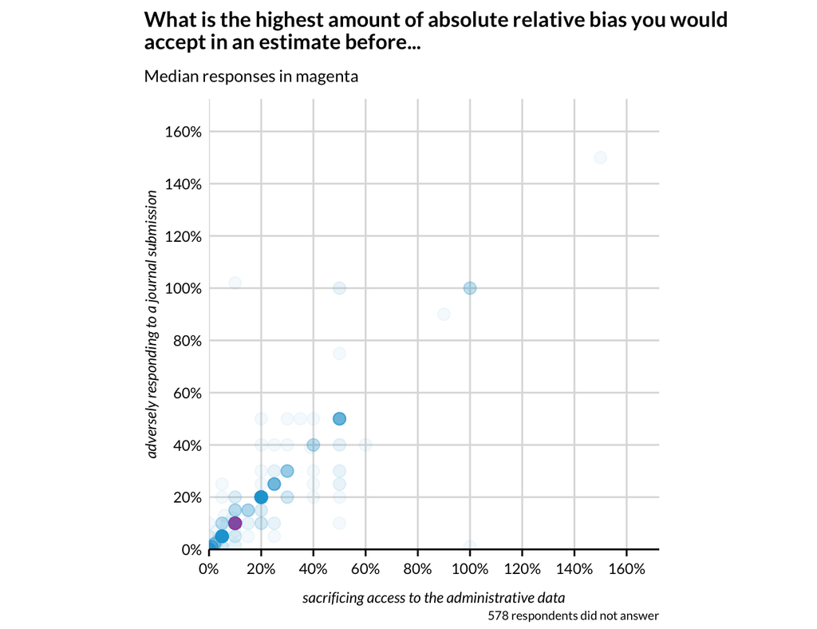

```r
ggplot() +
  geom_point(
    data = aea,
    mapping = aes(Q4_3_1 / 100, Q4_3_2 / 100),
    alpha = 0.05
  ) +
  geom_point(
    data = summarize(aea, Q4_3_1 = median(Q4_3_1, na.rm = TRUE), Q4_3_2 = median(Q4_3_2, na.rm = TRUE)),
    mapping = aes(Q4_3_1 / 100, Q4_3_2 / 100),
    alpha = 0.5,
    color = "#ec008b"
  ) +
  scale_x_continuous(
    breaks = seq(0, 1.6, 0.2),
    expand = expansion(mult = c(0, 0.15)),
    labels = scales::percent_format(accuracy = 1)
  ) +
  scale_y_continuous(
    breaks = seq(0, 1.6, 0.2),
    expand = expansion(mult = c(0, 0.15)),
    labels = scales::percent_format(accuracy = 1)
  ) +
  scatter_grid() +
  coord_equal() +
  labs(
    title = "What is the highest amount of absolute relative bias you would\naccept in an estimate before...",
    subtitle = "Median responses in magenta",
    x = "sacrificing access to the administrative data",
    y = "adversely responding to a journal submission",
    caption = "578 respondents did not answer"
  )
```

### 5.4 Question 4

What is the largest confidence interval ratio you would accept in an estimate before…?

```r
count(aea, is.na(Q4_4_1))
```

| is.na(Q4_4_1) | n |
| --- | --- |
| FALSE | 445 |
| TRUE | 583 |

```r
count(aea, is.na(Q4_4_2))
```

| is.na(Q4_4_2) | n |
| --- | --- |
| FALSE | 442 |
| TRUE | 586 |

```r
probs <- c(0, 0.05, 0.25, 0.5, 0.75, 0.95, 1)

aea %>%
  summarize(
    probs = probs,
    ci_ratio = quantile(Q4_4_1, probs = probs, na.rm = TRUE)
  )
```

| probs | ci_ratio |
| --- | --- |
| 0.00 | 1.0 |
| 0.05 | 1.0 |
| 0.25 | 1.1 |
| 0.50 | 1.3 |
| 0.75 | 2.0 |
| 0.95 | 24.0 |
| 1.00 | 10000.0 |

```r
aea %>%
  summarize(
    probs = probs,
    ci_ratio = quantile(Q4_4_2, probs = probs, na.rm = TRUE)
  )
```

| probs | ci_ratio |
| --- | --- |
| 0.00 | 1.00 |
| 0.05 | 1.00 |
| 0.25 | 1.10 |
| 0.50 | 1.25 |
| 0.75 | 2.00 |
| 0.95 | 25.00 |
| 1.00 | 100000.00 |

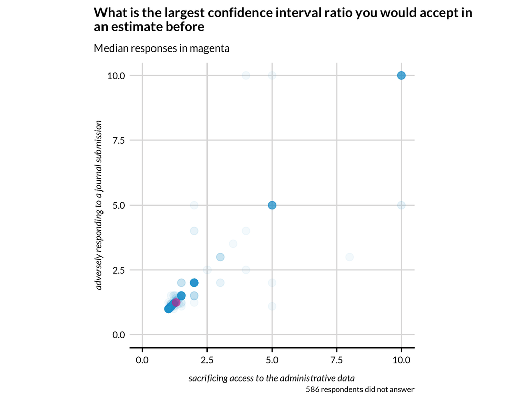

```r
ggplot() +
  geom_point(
    data = aea,
    mapping = aes(Q4_4_1, Q4_4_2),
    alpha = 0.05
  ) +
  geom_point(
    data = summarize(aea, Q4_4_1 = median(Q4_4_1, na.rm = TRUE), Q4_4_2 = median(Q4_4_2, na.rm = TRUE)),
    mapping = aes(Q4_4_1, Q4_4_2),
    alpha = 0.5,
    color = "#ec008b"
  ) +
  scale_x_continuous(limits = c(0, 10)) +
  scale_y_continuous(limits = c(0, 10)) +
  scatter_grid() +
  coord_equal() +
  labs(
    title = "What is the largest confidence interval ratio you would accept in\nan estimate before",
    subtitle = "Median responses in magenta",
    x = "sacrificing access to the administrative data",
    y = "adversely responding to a journal submission",
    caption = "586 respondents did not answer"
  )
```

## 6 Section 5

### 6.1 Question 1

5.1: Suppose you gain access to administrative data for regression analysis, but your access is constrained by a privacy budget. How would you spend your privacy budget from the following choices?

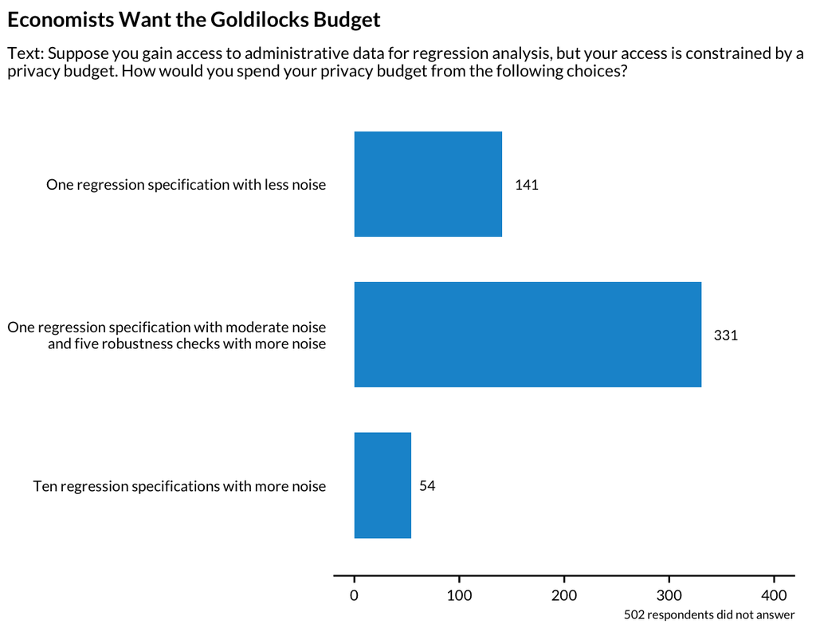

```r
aea %>%
  count(Q5_1) %>%
  filter(n != 502) %>%
  mutate(Q5_1 = fct_recode(
    Q5_1,
    `One regression specification with moderate noise\nand five robustness checks with more noise` =
      "One regression specification with moderate noise and five robustness checks with more   noise")
  ) %>%
  mutate(Q5_1 = fct_rev(Q5_1)) %>%
  ggplot(aes(n, Q5_1)) +
  geom_col() +
  geom_text(aes(label = n), hjust = -0.5) +
  scale_x_continuous(limits = c(NA, 400)) +
  labs(
    title = "Economists Want the Goldilocks Budget",
    subtitle = "Text: Suppose you gain access to administrative data for regression analysis, but your access is constrained by a\nprivacy budget. How would you spend your privacy budget from the following choices?",
    x = NULL,
    y = NULL,
    caption = "502 respondents did not answer"
  ) +
  theme(panel.grid = element_blank())
```

## 7 Software

## 8 Conclusions

- The respondents look like members of the AEA.
- Linear regression and merging data are essential methods.
- Estimated coefficients and standard errors are essential information from regression models.
- Most economists are unfamiliar with differential privacy and formal privacy.
- The economists who are familiar with differential privacy are skeptical of differential privacy.
- Economists want very modest amounts of error from formally private methods.
- Economists seem to have similar standards for the error metrics regardless of if it is their own work or someone else’s refereed work.
- Economists want the Goldilocks budget